# Population stratification using GRM and Jacard

Andrey Ziyatdinov

2017-07-12

# About

Population stratification is an important part of association studies conducted in a population consisting of different sub-populations. The standard approach exploited in the analysis of common genetic markers is to estimate generic relatedness matrix (GRM) (Patterson, Price, and Reich 2006). Recently, (Prokopenko et al. 2015) proposed to use Jacard similarity matrix in the analysis of rare variants. Here, we show practical examples on population stratification using R package bigcov in the following settings.

| Simulation | MAF range | Number of samples | Number of Markers | Relationship |
| --- | --- | --- | --- | --- |
| Common SNPs | [0.05; 0.5] | 200 | 1,000 | GRM |
| Rare SNPs | [0.001; 0.005] | 200 | 1,000 | GRM |
| Rare SNPs | [0.001; 0.005] | 200 | 1,000, 2,000 & 4,000 | Jacard |

## Work-horse functions in `bigcov`

Functions `bigdat_grm` and `bigdat_jacard` take input genotype data and convert them in `bigdat` format (also part of `bigcov`), which has a few practical features:

- support of several formats, including `matrix`, `big.matrix` from R package [bigmemory](https://cran.r-project.org/web/packages/bigmemory/) and plink via R package BEDMatrix;
- avoid loading the whole data matrix into RAM (for the later two formats) and split the data into batches (either `num_batches` or `batch_size` arguments);
  - splitting into batches improves the performance, as shown by [SNPRelate](http://corearray.sourceforge.net/tutorials/SNPRelate/)
- support of several `bigmemory` or plink files, e.g. files per chromosomes;
- parallel computing (coming soon).

# Preliminaries

```r
library(BEDMatrix) # to read plink data efficiently

library(RSpectra) # to perform PCA with a few components, e.g. 2

#library(bigcov)
library(devtools)
load_all("~/git/variani/bigcov/")
```

## Function to simulate two populations

A toy example is adopted from https://cran.r-project.org/web/packages/jacpop.

```r
sim_pop <- function(N = 200, M = 1000, Fst = 0.1, maf_max = 0.5, maf_min = 0.05,
  seed = 1)
{
  set.seed(seed)

  maf_values <- runif(M, maf_min, maf_max)

  freq1 <- sapply(1:M, function(i) rbeta(1,
    maf_values[i] * (1 - Fst) / Fst,
    (1 - maf_values[i]) * (1 - Fst) / Fst))
  freq2 <- sapply(1:M, function(i) rbeta(1,
    maf_values[i] * (1 - Fst) / Fst,
    (1 - maf_values[i]) * (1 - Fst) / Fst))

  gdat1 <- sapply(1:M, function(i) sample(c(0, 1, 2), N, replace = TRUE,
    prob = c(((1 - freq1[i])^2), (2 * freq1[i] * (1 - freq1[i])), (freq1[i]^2))))
  gdat2 <- sapply(1:M, function(i) sample(c(0, 1, 2), N, replace = TRUE,
    prob = c(((1 - freq2[i])^2), (2 * freq2[i] * (1 - freq2[i])), (freq2[i]^2))))

  gdat <- rbind(gdat1, gdat2)

  return(gdat)
}
```

## Function to plot PCA

```r
plot_pop <- function(mod, labs, ...)
{
  if(missing(labs)) {
    labs <- factor(rep("Pop", nrow(mod$vectors)))
  }

  plot(mod$vectors[, 1], mod$vectors[, 2], type = "n",
    xlab = "PC1", ylab = "PC2", ...)
  text(mod$vectors[, 1], mod$vectors[, 2], label = labs, col = as.numeric(labs))
}
```

# Default simulation parameters

```r
N <- 200 # the number of individuals per population
M <- 1e3 # the number of SNPs
Fst <- 0.01
```

# Common SNPs

```r
# simulated genotype data
gdat <- sim_pop(N = N, M = M, Fst = Fst, maf_max = 0.5, maf_min = 0.05, seed = 1)

# compute GRM
A <- bigdat_grm(gdat, check_na = FALSE, num_batches = 2, verbose = 2)
```

```
 - bigdat_tcrossprod: computing `tcrossprod`: 2 batches
 - batch 1 / 2
  -- filters: mono /  /  /
  -- clean markers ready for the analysis: 500 / 500
 - batch 2 / 2
  -- filters: mono /  /  /
  -- clean markers ready for the analysis: 500 / 500
 - clean markers used in the analysis: 1000 / 1000
```

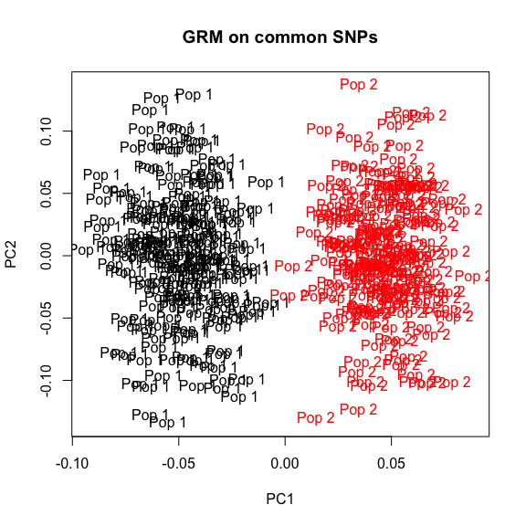

```r
# copmute PCA on GRM
mod <- eigs(A, k = 2)

# plot
labs <- factor(c(rep("Pop 1", N), rep("Pop 2", N)))
plot_pop(mod, labs, main = "GRM on common SNPs")
```

# Rare SNPs

## Population stratification using GRM

```r
# simulated genotype data
gdat <- sim_pop(N = N, M = M, Fst = Fst, maf_max = 0.005, maf_min = 0.001, seed = 1)

# compute GRM
A <- bigdat_grm(gdat, check_na = FALSE, num_batches = 2, verbose = 2)
```

```
 - bigdat_tcrossprod: computing `tcrossprod`: 2 batches
 - batch 1 / 2
  -- filters: mono /  /  /
   --- filtered mono. markers: 206 / 500
  -- clean markers ready for the analysis: 294 / 500
 - batch 2 / 2
  -- filters: mono /  /  /
   --- filtered mono. markers: 211 / 500
  -- clean markers ready for the analysis: 289 / 500
 - clean markers used in the analysis: 583 / 1000
```

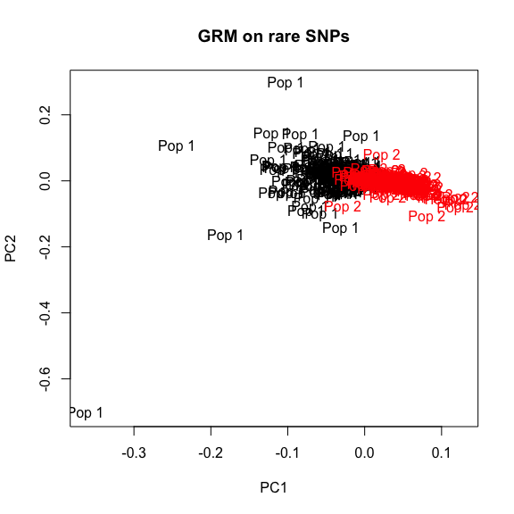

```r
# copmute PCA on GRM
mod <- eigs(A, k = 2)

# plot
labs <- factor(c(rep("Pop 1", N), rep("Pop 2", N)))
plot_pop(mod, labs, main = "GRM on rare SNPs")
```

## Population stratification using Jacard

```r
# simulated genotype data
# - the same data as in the previous example, as the seed value is the same (1)
gdat <- sim_pop(N = N, M = M, Fst = Fst, maf_max = 0.005, maf_min = 0.001, seed = 1)

# compute Jacard
A <- bigdat_jacard(gdat, num_batches = 2, verbose = 2)
```

```
 - bigdat_jacard: computing: 2 batches
 - batch 1 / 2
 - batch 2 / 2
```

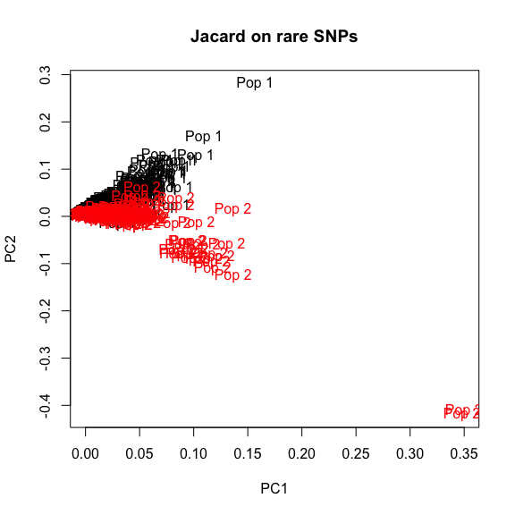

```r
# copmute PCA on GRM
mod <- eigs(A, k = 2)

# plot
labs <- factor(c(rep("Pop 1", N), rep("Pop 2", N)))
plot_pop(mod, labs, main = "Jacard on rare SNPs")
```

## Population stratification using Jacard and more SNPs

```r
# simulated genotype data
# - the simulated data is different, as we double the number of SNPs
M2 <- 2*M
gdat <- sim_pop(N = N, M = M2, Fst = Fst, maf_max = 0.005, maf_min = 0.001, seed = 1)

# compute Jacard
A <- bigdat_jacard(gdat, num_batches = 2, verbose = 2)
```

```
 - bigdat_jacard: computing: 2 batches
 - batch 1 / 2
 - batch 2 / 2
```

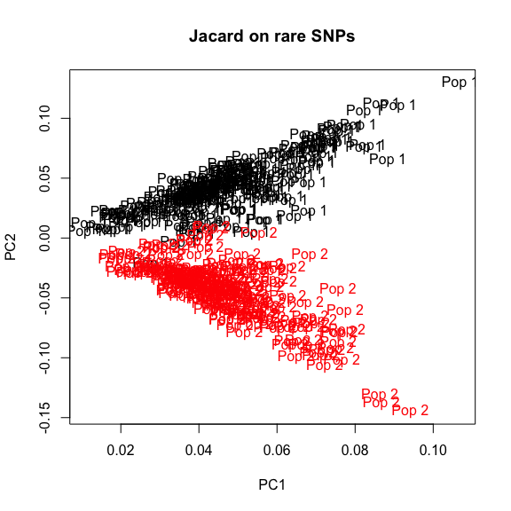

```r
# copmute PCA on GRM
mod <- eigs(A, k = 2)

# plot
labs <- factor(c(rep("Pop 1", N), rep("Pop 2", N)))
plot_pop(mod, labs, main = "Jacard on rare SNPs")
```

## Population stratification using Jacard and even more SNPs

```r
M4 <- 4*M
gdat <- sim_pop(N = N, M = M4, Fst = Fst, maf_max = 0.005, maf_min = 0.001, seed = 1)

# compute Jacard
A <- bigdat_jacard(gdat, num_batches = 2, verbose = 2)
```

```
 - bigdat_jacard: computing: 2 batches
 - batch 1 / 2
 - batch 2 / 2
```

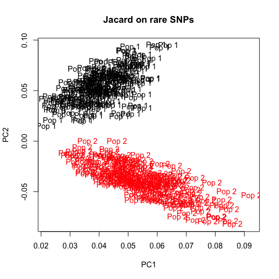

```r
# copmute PCA on GRM
mod <- eigs(A, k = 2)

# plot
labs <- factor(c(rep("Pop 1", N), rep("Pop 2", N)))
plot_pop(mod, labs, main = "Jacard on rare SNPs")
```

# Example with plink files

We use dummy data in plink format from R package BEDMatrix.

```r
path <- system.file("extdata", "example.bed", package = "BEDMatrix")
bmat <- BEDMatrix(path)

bmat
```

```
BEDMatrix: 50 x 1000 [/usr/local/Cellar/r/3.4.0_1/R.framework/Versions/3.4/Resources/library/BEDMatrix/extdata/example.bed]
```

```r
dim(bmat)
```

```
[1]   50 1000
```

```r
bmat[1:5, 1:5]
```

```
          snp0_A snp1_C snp2_G snp3_G snp4_G
per0_per0      0      1      1      1      0
per1_per1      1      1      1      1     NA
per2_per2      1      0      0      2      0
per3_per3      2      0      0      0      1
per4_per4      0      1      0      0      0
```

```r
N <- nrow(bmat)

grm <- bigdat_grm(bmat, num_batches = 2, verbose = 2)
```

```
 - bigdat_tcrossprod: computing `tcrossprod`: 2 batches
 - batch 1 / 2
  -- filters: mono /  /  / check_na
  -- clean markers ready for the analysis: 500 / 500
  -- # NAs 0
 - batch 2 / 2
  -- filters: mono /  /  / check_na
  -- clean markers ready for the analysis: 500 / 500
  -- # NAs 0
 - clean markers used in the analysis: 1000 / 1000
```

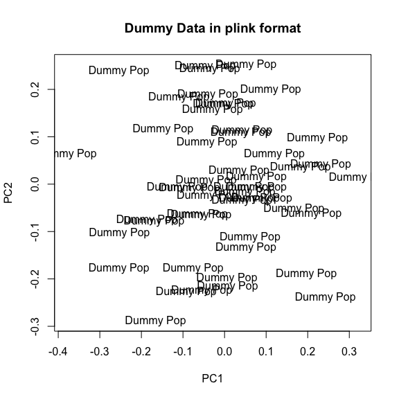

```r
mod <- eigs(grm, k = 2)

labs <- factor(rep("Dummy Pop", N))
plot_pop(mod, labs, main = "Dummy Data in plink format")
```

# Future work

We need to test examples not covered in this document:

- real genotype data, e.g. 100K individual and 10M genotypes;
- parallel computing and splitting into many batches.

That will give us an idea whether R is powerful enough for big data in genetics (spoiler: yes, it is).

# License

This document is licensed under the Creative Commons Attribution 4.0 International Public License.

# References

Patterson, Nick, Alkes L Price, and David Reich. 2006. “Population Structure and Eigenanalysis.” *PLoS Genetics* 2 (12). Public Library of Science: e190.

Prokopenko, Dmitry, Julian Hecker, Edwin K Silverman, Marcello Pagano, Markus M Nöthen, Christian Dina, Christoph Lange, and Heide Loehlein Fier. 2015. “Utilizing the Jaccard Index to Reveal Population Stratification in Sequencing Data: A Simulation Study and an Application to the 1000 Genomes Project.” *Bioinformatics* 32 (9). Oxford University Press: 1366–72.